# Machine Learning Engineer Nanodegree

### PFE

```
testing error = 0.000104524868479
```

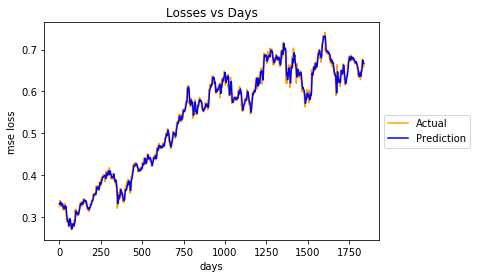

```python
X_test_PFE_reshaped = np.asarray(np.reshape(X_test_PFE, (X_test_PFE.shape[0], window_size, 1)))
test_predict_PFE = model.predict(X_test_PFE_reshaped)

testing_error = model.evaluate(X_test_PFE_reshaped, y_test_PFE, verbose=0)
print('testing error = ' + str(testing_error))

plt.plot(y_test_PFE, color='orange')
plt.plot(test_predict_PFE, color='blue')
plt.title("Losses vs Days")
plt.ylabel("mse loss")
plt.xlabel("days")
plt.legend(['Actual','Prediction'],loc='center left', bbox_to_anchor=(1, 0.5))
```

### WMT

```
testing error = 0.000148270152752
```

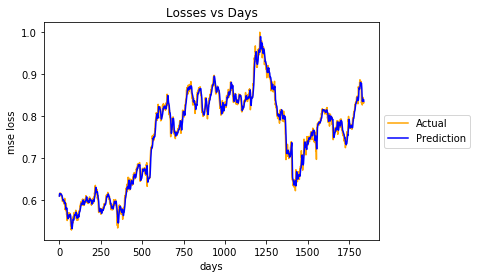

```python
X_test_WMT_reshaped = np.asarray(np.reshape(X_test_WMT, (X_test_WMT.shape[0], window_size, 1)))
test_predict_WMT = model.predict(X_test_WMT_reshaped)

testing_error = model.evaluate(X_test_WMT_reshaped, y_test_WMT, verbose=0)
print('testing error = ' + str(testing_error))

plt.plot(y_test_WMT, color='orange')
plt.plot(test_predict_WMT, color='blue')
plt.title("Losses vs Days")
plt.ylabel("mse loss")
plt.xlabel("days")
plt.legend(['Actual','Prediction'],loc='center left', bbox_to_anchor=(1, 0.5))
```

### XOM

```
testing error = 0.000225811419423
```

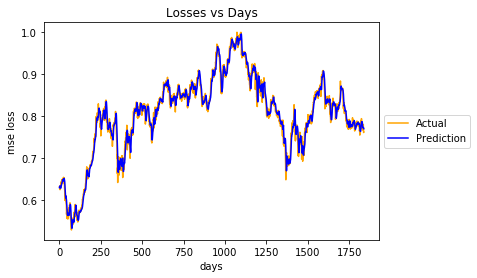

```python
X_test_XOM_reshaped = np.asarray(np.reshape(X_test_XOM, (X_test_XOM.shape[0], window_size, 1)))
test_predict_XOM = model.predict(X_test_XOM_reshaped)

testing_error = model.evaluate(X_test_XOM_reshaped, y_test_XOM, verbose=0)
print('testing error = ' + str(testing_error))

plt.plot(y_test_XOM, color='orange')
plt.plot(test_predict_XOM, color='blue')
plt.title("Losses vs Days")
plt.ylabel("mse loss")
plt.xlabel("days")
plt.legend(['Actual','Prediction'],loc='center left', bbox_to_anchor=(1, 0.5))
```

### MYL

```
testing error = 0.000338295598075
```

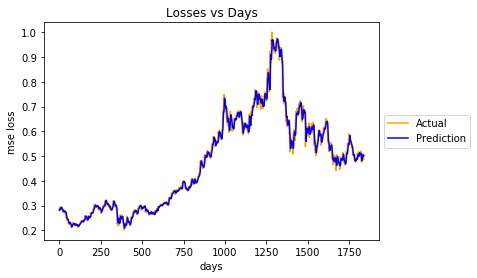

```python
X_test_MYL_reshaped = np.asarray(np.reshape(X_test_MYL, (X_test_MYL.shape[0], window_size, 1)))
test_predict_MYL = model.predict(X_test_MYL_reshaped)

testing_error = model.evaluate(X_test_MYL_reshaped, y_test_MYL, verbose=0)
print('testing error = ' + str(testing_error))

plt.plot(y_test_MYL, color='orange')
plt.plot(test_predict_MYL, color='blue')
plt.title("Losses vs Days")
plt.ylabel("mse loss")
plt.xlabel("days")
plt.legend(['Actual','Prediction'],loc='center left', bbox_to_anchor=(1, 0.5))
```

### AAPL

```
testing error = 0.000207465001509
```

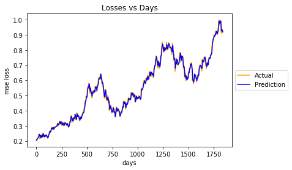

```python
X_test_AAPL_reshaped = np.asarray(np.reshape(X_test_AAPL, (X_test_AAPL.shape[0], window_size, 1)))
test_predict_AAPL = model.predict(X_test_AAPL_reshaped)

testing_error = model.evaluate(X_test_AAPL_reshaped, y_test_AAPL, verbose=0)
print('testing error = ' + str(testing_error))

plt.plot(y_test_AAPL, color='orange')
plt.plot(test_predict_AAPL, color='blue')
plt.title("Losses vs Days")
plt.ylabel("mse loss")
plt.xlabel("days")
plt.legend(['Actual','Prediction'],loc='center left', bbox_to_anchor=(1, 0.5))
```

### GOOG

```
testing error = 0.000326079051696
```

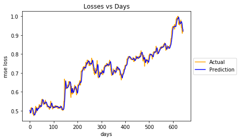

```python
X_test_GOOG_reshaped = np.asarray(np.reshape(X_test_GOOG, (X_test_GOOG.shape[0], window_size, 1)))
test_predict_GOOG = model.predict(X_test_GOOG_reshaped)

testing_error = model.evaluate(X_test_GOOG_reshaped, y_test_GOOG, verbose=0)
print('testing error = ' + str(testing_error))

plt.plot(y_test_GOOG, color='orange')
plt.plot(test_predict_GOOG, color='blue')
plt.title("Losses vs Days")
plt.ylabel("mse loss")
plt.xlabel("days")
plt.legend(['Actual','Prediction'],loc='center left', bbox_to_anchor=(1, 0.5))
```

# Benchmark Models

### Following benchmark models are considered

- Moving Averages
- Linear Regression
- KNN
- Support vector machines (RBF)
- Support vector machines (Poly)

# Moving averages

```python
avg = np.mean(X_test,axis=1)
```

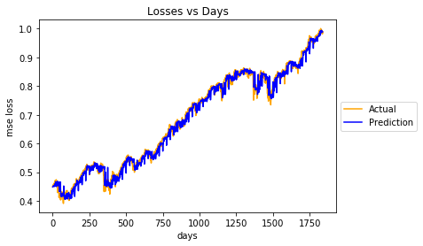

```python
plt.plot(y_test, color='orange')
plt.plot(avg, color='blue')
plt.title("Losses vs Days")
plt.ylabel("mse loss")
plt.xlabel("days")
plt.legend(['Actual','Prediction'],loc='center left', bbox_to_anchor=(1, 0.5))
```

```python
testing_error_MovingAvg = mean_squared_error(avg, y_test)
print('Testing Error: %.8f MSE (%.8f RMSE)' % (testing_error_MovingAvg, np.sqrt(testing_error_MovingAvg)))
```

```
Testing Error: 0.00031200 MSE (0.01766339 RMSE)
```

# Linear Regression

```python
from sklearn import linear_model
from sklearn.metrics import mean_squared_error, r2_score
```

```python
regr = linear_model.LinearRegression()

# Train the model using the training sets
regr.fit(X_train_initial, y_train)
#regr.fit(a, y_train)

# Make predictions using the testing set
y_preds = regr.predict(X_test_initial)
```

```python
testing_error_LinReg = mean_squared_error(y_preds, y_test)
print('Testing Error: %.8f MSE (%.8f RMSE)' % (testing_error_LinReg, np.sqrt(testing_error_LinReg)))
```

```
Testing Error: 0.00041431 MSE (0.02035455 RMSE)
```

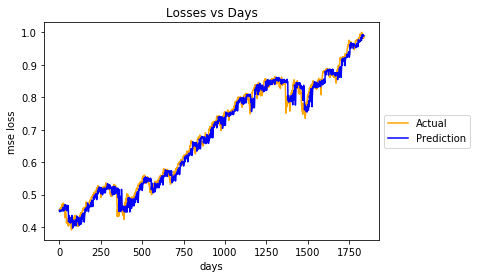

```python
plt.plot(y_test, color='orange')
plt.plot(y_preds, color='blue')
plt.title("Losses vs Days")
plt.ylabel("mse loss")
plt.xlabel("days")
plt.legend(['Actual','Prediction'],loc='center left', bbox_to_anchor=(1, 0.5))
```

# KNN

```python
from sklearn.neighbors import KNeighborsRegressor
```

```python
neigh = KNeighborsRegressor(n_neighbors=2)
```

```python
neigh.fit(X_train_initial, y_train)
```

```
KNeighborsRegressor(algorithm='auto', leaf_size=30, metric='minkowski',
          metric_params=None, n_jobs=1, n_neighbors=2, p=2,
          weights='uniform')
```

```python
y_pred = neigh.predict(X_test_initial)
```

```python
testing_error_KNN = mean_squared_error(y_pred, y_test)
print('Testing Error: %.8f MSE (%.8f RMSE)' % (testing_error_KNN, np.sqrt(testing_error_KNN)))
```

```
Testing Error: 0.03227614 MSE (0.17965563 RMSE)
```

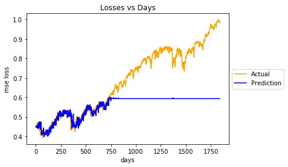

```python
plt.plot(y_test, color='orange')
plt.plot(y_pred, color='blue')
plt.title("Losses vs Days")
plt.ylabel("mse loss")
plt.xlabel("days")
plt.legend(['Actual','Prediction'],loc='center left', bbox_to_anchor=(1, 0.5))
```

## Support Vector Machine Model - RBF

```python
from sklearn.svm import SVR
```

```python
svr_rbf = SVR(kernel= 'rbf', C= 1e3, gamma= 0.1)
```

```python
svr_rbf.fit(X_train_initial, y_train)
```

```
SVR(C=1000.0, cache_size=200, coef0=0.0, degree=3, epsilon=0.1, gamma=0.1,
  kernel='rbf', max_iter=-1, shrinking=True, tol=0.001, verbose=False)
```

```python
y_pred = svr_rbf.predict(X_test_initial)
```

```python
testing_error_SVCrbf = mean_squared_error(y_pred, y_test)
print('Testing Error: %.8f MSE (%.8f RMSE)' % (testing_error_SVCrbf, np.sqrt(testing_error_SVCrbf)))
```

```
Testing Error: 0.02063948 MSE (0.14366447 RMSE)
```

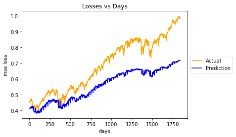

```python
plt.plot(y_test, color='orange')
plt.plot(y_pred, color='blue')
plt.title("Losses vs Days")
plt.ylabel("mse loss")
plt.xlabel("days")
plt.legend(['Actual','Prediction'],loc='center left', bbox_to_anchor=(1, 0.5))
```

## Support Vector Machine Model - Poly

```python
svr_poly = SVR(kernel= 'poly', C= 1e3, degree= 1)
```

```python
svr_poly.fit(X_train_initial, y_train)
```

```
SVR(C=1000.0, cache_size=200, coef0=0.0, degree=1, epsilon=0.1, gamma='auto',
  kernel='poly', max_iter=-1, shrinking=True, tol=0.001, verbose=False)
```

```python
y_pred = svr_poly.predict(X_test_initial)
```

```python
testing_error_SVCpoly = mean_squared_error(y_pred, y_test)
print('Testing Error: %.8f MSE (%.8f RMSE)' % (testing_error_SVCpoly, np.sqrt(testing_error_SVCpoly)))
```

```
Testing Error: 0.01464977 MSE (0.12103624 RMSE)
```

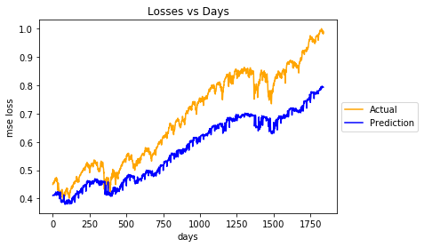

```python
plt.plot(y_test, color='orange')
plt.plot(y_pred, color='blue')
plt.title("Losses vs Days")
plt.ylabel("mse loss")
plt.xlabel("days")
plt.legend(['Actual','Prediction'],loc='center left', bbox_to_anchor=(1, 0.5))
```

### Results for various Window Sizes and Batch Sizes

### Batch_size = 256

```python
planets = [
    ['Window_Size', 'Test_Data_Size','SP500_Training_Error', 'SP500 Validation Error','SP500 Test Error', 'IBM Test Error' ,  'Moving Averages', 'LinearRegression' ,'KNN' ,  'SVC RBF', 'SVC Poly'],
    ['5', 1834,  '0.00004078', '0.00007534', '0.00010047', '0.00025746', '0.00031200', '0.00041431', '0.03227614', '0.02063950', '0.01464979'],
    ['10', 1834, '0.00006683', '0.00012114', '0.00021127', '0.00042141', '0.00029952', '0.00054327', '0.03261012', '0.02372918', '0.01130500'],
    ['25', 1834, '0.00008527', '0.00018637', '0.00045830', '0.00073806', '0.00038604', '0.00088376', '0.03746455', '0.04741630', '0.00838335'],
    ['50', 1834, '0.00010575', '0.00024435', '0.00112720', '0.00159768', '0.00055406', '0.00188684', '0.03814208', '0.07295037', '0.00999640'],
    ['75', 1834, '0.00006819', '0.00014890', '0.00018894', '0.00046954', '0.00070063', '0.00041257', '0.03899267', '0.08549924', '0.01116770'],
    ['100', 1834, '0.00007315', '0.00016924', '0.00040543', '0.00072450', '0.00091074', '0.00072633', '0.04193859', '0.09606416', '0.01167342'],
    ['150', 1834, '0.00004967', '0.00012329', '0.00036009', '0.00063898', '0.00145170', '0.00072645', '0.05042111', '0.11851730', '0.01064598']];
make_table(planets)
```

| Window_Size | Test_Data_Size | SP500_Training_Error | SP500 Validation Error | SP500 Test Error | IBM Test Error | Moving Averages | LinearRegression | KNN | SVC RBF | SVC Poly |
| --- | --- | --- | --- | --- | --- | --- | --- | --- | --- | --- |
| 5 | 1834 | 0.00004078 | 0.00007534 | 0.00010047 | 0.00025746 | 0.00031200 | 0.00041431 | 0.03227614 | 0.02063950 | 0.01464979 |
| 10 | 1834 | 0.00006683 | 0.00012114 | 0.00021127 | 0.00042141 | 0.00029952 | 0.00054327 | 0.03261012 | 0.02372918 | 0.01130500 |
| 25 | 1834 | 0.00008527 | 0.00018637 | 0.00045830 | 0.00073806 | 0.00038604 | 0.00088376 | 0.03746455 | 0.04741630 | 0.00838335 |
| 50 | 1834 | 0.00010575 | 0.00024435 | 0.00112720 | 0.00159768 | 0.00055406 | 0.00188684 | 0.03814208 | 0.07295037 | 0.00999640 |
| 75 | 1834 | 0.00006819 | 0.00014890 | 0.00018894 | 0.00046954 | 0.00070063 | 0.00041257 | 0.03899267 | 0.08549924 | 0.01116770 |
| 100 | 1834 | 0.00007315 | 0.00016924 | 0.00040543 | 0.00072450 | 0.00091074 | 0.00072633 | 0.04193859 | 0.09606416 | 0.01167342 |
| 150 | 1834 | 0.00004967 | 0.00012329 | 0.00036009 | 0.00063898 | 0.00145170 | 0.00072645 | 0.05042111 | 0.11851730 | 0.01064598 |

```python
TrainingError = (0.00004078,0.00006683,0.00008527, 0.00010575,0.00006819, 0.00007315, 0.00004967)
ValiDationError = (0.00007534, 0.00012114, 0.00018637, 0.00024435, 0.00014890, 0.00016924 , 0.00012329)
TestingError = (0.00010047, 0.00021127, 0.00045830, 0.00112720,  0.00018894, 0.00040543, 0.00036009 )
df = pd.DataFrame({"TrainingError":TrainingError, "ValidationError":ValiDationError,"TestingError":TestingError},index=(5,10,25,50,75,100, 150))
```

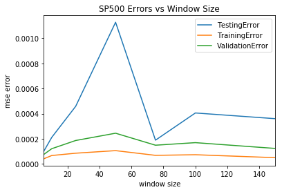

```python
ax = df.plot(title="SP500 Errors vs Window Size")
ax.set_xlabel("window size")
ax.set_ylabel("mse error")
```

#### As per above data, window_size = 5 gives best performance for all 3 types of errors

### Batch_size = 512

```python
#Batch_size = 512

planets = [
    ['Window_Size', 'Test_Data_Size','SP500_Training_Error', 'SP500 Validation Error','SP500 Test Error', 'IBM Test Error' ,  'Moving Averages', 'LinearRegression', 'SVC RBF', 'SVC Poly','KNN'],
    ['5',  1834, '0.00003232', '0.00007532', '0.00013725', '0.00029440', '0.00039415', '0.00058431', '0.03227943', '0.02142875', '0.01562921'],
    ['25',  1834, '0.00005051', '0.00012183', '0.00021270', '0.00045178', '0.00035162', '0.00048246', '0.03740064', '0.04744647', '0.00812207'],
    ['50', 1834, '0.00005389', '0.00012219', '0.00030047', '0.00055888', '0.00052721', '0.00061802', '0.03807823', '0.07310377', '0.00977757'],
    ['75', 1834, '0.00005042', '0.00012001', '0.00025320', '0.00050345', '0.00070379', '0.00054486', '0.03898876', '0.08543254', '0.01121154'],
    ['100', 1834, '0.00005573', '0.00011759', '0.00024905', '0.00049787', '0.00090326', '0.00054583', '0.04189907', '0.09609359', '0.01164647'],
    ['150', 1834, '0.00004930', '0.00012021', '0.00031760', '0.00057828', '0.00145105', '0.00067420', '0.05040070', '0.11852902', '0.01063873'],
];
make_table(planets)
```

[output not shown]

### Batch_size = 128

```python
planets = [
    ['Window_Size', 'Test_Data_Size','SP500_Training_Error', 'SP500 Validation Error','SP500 Test Error', 'IBM Test Error' ,  'Moving Averages', 'LinearRegression', 'SVC RBF', 'SVC Poly','KNN'],
    ['5',  1834, '0.00003218', '0.00007570', '0.00021764', '0.00039567', '0.00053664', '0.00089530', '0.03228318', '0.02214328', '0.01650797'],
    ['25',  1834, '0.00005388', '0.00011904', '0.00050521', '0.00080897', '0.00038957', '0.00100944', '0.03743437', '0.04734198', '0.00843040' ],
    ['50', 1834, '0.00007606', '0.00023419', '0.00217494', '0.00304926', '0.00057463', '0.00384614', '0.03818647', '0.07281140', '0.01017769'],
    ['75', 1834, '0.00009758', '0.00014957', '0.00021132', '0.00056780', '0.00069160', '0.00042570', '0.03898671', '0.08561985', '0.01109281'],
    ['100', 1834, '0.00006949', '0.00019796', '0.00213623', '0.00301003', '0.00094388', '0.00377920', '0.04205134', '0.09584002', '0.01186669'],
    ['150', 1834,'0.00004794', '0.00011323', '0.00073453', '0.00111262', '0.00146301', '0.00146623', '0.05066706', '0.11845107', '0.01073395'],
];
make_table(planets)
```

[output not shown]

```python
# Window_size = 5
TestError_bs_128 = (0.00021764, 0.00050521, 0.00217494, 0.00021132, 0.00213623, 0.00073453 )
TestError_bs_256 = (0.00010047, 0.00045830, 0.00112720, 0.00018894, 0.00040543, 0.00036009)
TestError_bs_512 = (0.00013725, 0.00021270, 0.00030047, 0.00025320, 0.00024905, 0.00031760 )
```

```python
df_bs = pd.DataFrame({"TestError_bs_128": TestError_bs_128, "TestError_bs_256":TestError_bs_256, "TestError_bs_512":TestError_bs_512 }, index = (5,25,50,75,100,150))
```

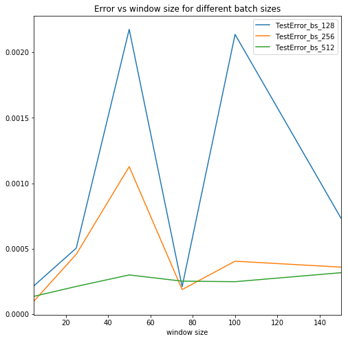

```python
ax_bs = df_bs.plot(title = "Error vs window size for different batch sizes", figsize = (8,8))
ax_bs.set_xlabel("window size")
ax.set_ylabel("mse error")
```

#### As per above graph, Test Error is lowest for batch size=256 for window size = 5

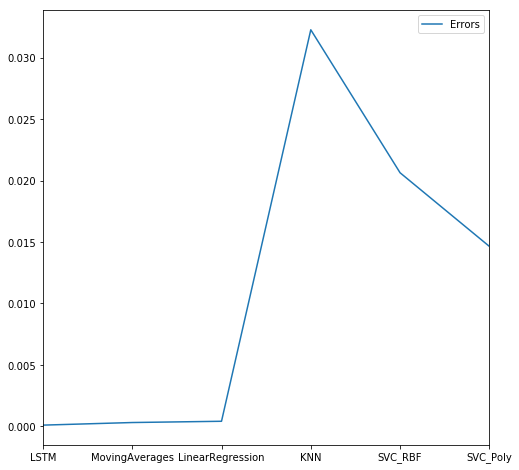

```python
# Window Size = 5, Batch Size = 256
Errors = (0.00010047, 0.00031200, 0.00041431, 0.03227614, 0.02063950, 0.01464979)
index = ('LSTM', 'MovingAverages', 'LinearRegression', 'KNN', 'SVC_RBF', 'SVC_Poly' )

df_models = pd.DataFrame({"Errors": Errors}, index=index)
df_models.plot(figsize = (8,8))
```

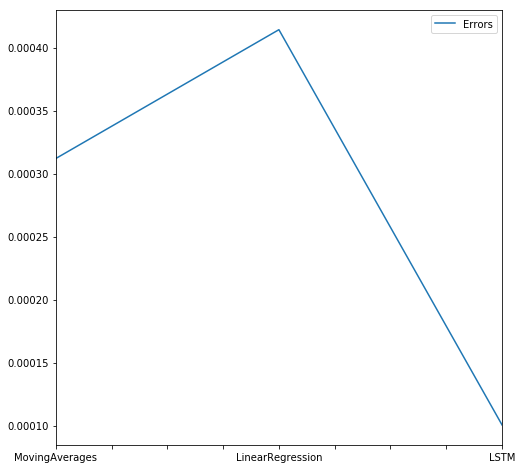

```python
TestingErrors = ( 0.00031200, 0.00041431, 0.00010047)
index = ( 'MovingAverages', 'LinearRegression', 'LSTM')

df_models = pd.DataFrame({"Errors": TestingErrors}, index=index)
df_models.plot(figsize=(8,8))
```

## Conclusion

#### The problem of predicting stock prices actually involves identifying patterns in sequences and LSTMs are designed to predict sequence patterns. LSTMs have been successfully used in identifying patterns in images, speech recognition and some attempt has been made to predict future time series. The results from this project show that LSTMs can be used successfully in predicting future prices.